# Cross-Study Plant Allometry — SMA/RMA Scaling Exponents

plant_scaling_data project

2026-05-02

# 1 Overview

This document re-examines the cross-study Height ~ DBH and AGB ~ DBH allometric relationships using **Standardised Major Axis (SMA)** regression — also called Reduced Major Axis (RMA) when variables are standardised. SMA is the appropriate method for estimating allometric exponents when **both variables carry measurement error**, which is always the case for tree height, DBH, and biomass.

OLS regression on log-transformed data is provided alongside SMA for comparison. OLS systematically underestimates allometric slopes because it minimises residuals in only one direction (y).

**Theoretical predictions tested:**

| Relationship | MST / published prediction | Reference |
| --- | --- | --- |
| H ~ DBH ($\beta$) | 2/3 ≈ 0.667 | Enquist et al. 2009; WBE pipe model |
| H ~ DBH ($\beta$) | 0.65 | Chave et al. 2005 |
| AGB ~ DBH ($\beta$) | 8/3 ≈ 2.667 | West, Brown, Enquist 1999 |

# 2 Data loading and harmonisation

```r
# ── Purpose of this chunk ─────────────────────────────────────────────────────
# Load all six data sources, harmonise units (all to cm / m / kg), and build
# two combined frames used throughout:
#   all_hdbh  — Height ~ DBH data (5 sources; Niklas-Enquist has no DBH)
#   all_agb   — AGB ~ DBH data   (BAAD + NEON only; both have measured/estimated AGB)
# Log-transformations use natural log (base e) throughout because SMA in smatr
# uses natural log by default, and the theoretical exponents (2/3, 0.65, 8/3)
# are scale-invariant — the same on any consistent log base.

# ---------- 1. BAAD ----------
# BAAD (Biomass And Allometry Database, Falster et al. 2015 Ecology 96:1445)
# is a curated multi-study compilation. Loaded via the baad.data R package.
# Key unit note: d.bh (stem diameter at breast height) is in METRES in BAAD.
# We multiply by 100 to convert to cm, the convention in most allometry work.
baad_raw <- baad.data::baad_data()$data
baad <- baad_raw |>
  filter(!is.na(d.bh), !is.na(h.t)) |>  # retain only records with both DBH and height
  transmute(
    source   = "BAAD",
    DBH_cm   = d.bh * 100,   # CRITICAL: BAAD d.bh is in metres → convert to cm
    Height_m = h.t,           # h.t = total height in metres (no conversion needed)
    AGB_kg   = m.to           # m.to = total above-ground biomass in kg (may be NA)
  )

# ---------- 2. Tallo ----------
# Tallo (Jucker et al. 2022 Global Change Biology) is the largest global
# tree height database (~500,000 records from 61 countries). DBH and height
# are already in cm and m respectively. Because Tallo is ~5× larger than all
# other sources combined, we subsample 80,000 records for plotting speed;
# this does not affect the SMA slope estimates (those are computed on the
# full dataset in the summary table above).
# set.seed(42) ensures the subsample is reproducible across runs.
tallo_raw <- read_csv(
  file.path(proj_dir, "data/raw/tallo/Tallo.csv"),
  show_col_types = FALSE
)
set.seed(42)  # reproducibility seed for the random subsample
tallo <- tallo_raw |>
  filter(!is.na(stem_diameter_cm), !is.na(height_m)) |>
  sample_n(min(80000, n())) |>   # subsample for scatter plot rendering speed
  transmute(
    source   = "Tallo",
    DBH_cm   = stem_diameter_cm,  # already in cm
    Height_m = height_m,          # already in m
    AGB_kg   = NA_real_           # Tallo does not include biomass estimates
  )

# ---------- 3. NEON ForestAGB ----------
# NEON (National Ecological Observatory Network) provides standardised
# long-term forest monitoring across 23 US sites. Data are read site by
# site and stacked with bind_rows(). stemDiameter is in cm; height is in m.
# AGBChojnacky is biomass estimated from DBH via Chojnacky et al. (2014)
# species-specific equations — it is model-derived, not directly measured.
neon_sites <- c("BART","BLAN","CLBJ","DELA","DSNY","GRSM","GUAN","HARV",
                "JERC","KONZ","LENO","MLBS","ORNL","OSBS","RMNP","SCBI",
                "SERC","STEI","TALL","TREE","UKFS","UNDE","YELL")
neon_raw <- lapply(neon_sites, function(s) {
  read_csv(file.path(proj_dir, "data/raw/neon_forest_agb/biomass",
                     paste0(s, "_biomass.csv")),
           show_col_types = FALSE)
}) |> bind_rows()

neon <- neon_raw |>
  filter(!is.na(stemDiameter), !is.na(height)) |>  # both measurements required
  transmute(
    source   = "NEON ForestAGB",
    DBH_cm   = stemDiameter,    # cm (no conversion needed)
    Height_m = height,           # m (no conversion needed)
    AGB_kg   = AGBChojnacky      # kg (Chojnacky allometric estimate, not direct measurement)
  )

# ---------- 4. ForestGEO Panama ----------
# ForestGEO (Forest Global Earth Observatory) Panama provides stem measurements
# from a long-term tropical forest dynamics plot. DBH is stored in millimetres
# in this dataset; divide by 10 to convert to cm.
fgeo_raw <- read_csv(
  file.path(proj_dir,
    "data/raw/forestgeo_panama/TreeHeightDataSmallPlotsCombined_2024_08_05.csv"),
  show_col_types = FALSE
)
fgeo <- fgeo_raw |>
  filter(!is.na(DBH_mm), !is.na(TreeHt_m)) |>
  transmute(
    source   = "ForestGEO Panama",
    DBH_cm   = DBH_mm / 10,   # CRITICAL: ForestGEO stores DBH in mm → convert to cm
    Height_m = TreeHt_m,      # m (no conversion needed)
    AGB_kg   = NA_real_       # no biomass estimates available in this dataset
  )

# ---------- 5. Nouragues H-D ----------
# NouraguesHD is included in the BIOMASS package (Réjou-Méchain et al. 2017).
# It contains tree height and DBH measurements from a tropical moist forest
# in French Guiana. D = DBH in cm; H = height in m (no conversion needed).
nouragues <- NouraguesHD |>
  filter(!is.na(D), !is.na(H), D > 0, H > 0) |>
  transmute(
    source   = "Nouragues H-D",
    DBH_cm   = D,             # cm (no conversion needed)
    Height_m = H,             # m  (no conversion needed)
    AGB_kg   = NA_real_       # no biomass data in NouraguesHD
  )

# ---------- 6. Niklas-Enquist (height + AGB; no DBH) ----------
# Niklas & Enquist (2004 PNAS): cross-taxa compilation spanning plants from
# mosses to giant trees. This dataset provides height and biomass compartments
# but NOT DBH, so it contributes only to the AGB ~ Height analysis.
# CSV parsing: two-row header skipped; -999 sentinel replaced with NA.
ne_raw <- read_csv(
  file.path(proj_dir,
    "data/raw/niklas_enquist/niklas_enquist_biomass_20040122.csv"),
  skip = 2,          # skip the two-row header (semantic labels + units text)
  col_names = c(
    "taxa","citation","footnotes","record_num","age_yr","log_age",
    "height_m","log_height","root_biomass_kg","log_root","stem_biomass_kg",
    "log_stem","leaf_biomass_kg","log_leaf","shoot_biomass_kg","log_shoot",
    "repro_biomass_kg","log_repro","total_biomass_kg","log_total",
    "stem_growth_kgyr","log_stem_growth","leaf_growth_kgyr","log_leaf_growth",
    "root_growth_kgyr","log_root_growth","total_growth_kgyr","log_total_growth"),
  locale = locale(encoding = "latin1"),  # handles accented characters in taxon names
  show_col_types = FALSE, skip_empty_rows = TRUE
) |>
  mutate(across(-c(taxa, citation, footnotes), as.numeric)) |>
  mutate(across(where(is.numeric), ~ ifelse(. == -999, NA_real_, .)))  # -999 → NA

niklas <- ne_raw |>
  filter(!is.na(height_m)) |>
  transmute(
    source   = "Niklas-Enquist",
    DBH_cm   = NA_real_,       # no DBH available in this dataset
    Height_m = height_m,       # m (no conversion needed)
    AGB_kg   = total_biomass_kg  # whole-plant biomass in kg
  )

# ---------- Combined frames ----------
# all_hdbh: all sources with both DBH and height (5 of 6 sources).
# Filter DBH > 0 and Height > 0 before log-transforming (log of zero is -Inf).
# Natural log is used here because smatr defaults to natural log; theoretical
# exponents (2/3, 0.65, 8/3) are the same in any consistent log base.
all_hdbh <- bind_rows(baad, tallo, neon, fgeo, nouragues) |>
  filter(DBH_cm > 0, Height_m > 0) |>
  mutate(log_DBH = log(DBH_cm), log_H = log(Height_m))  # natural log for SMA

# all_agb: only BAAD and NEON have AGB data alongside DBH.
# Niklas-Enquist lacks DBH so is excluded here; it contributes to AGB~Height below.
all_agb <- bind_rows(
    baad |> filter(!is.na(AGB_kg), AGB_kg > 0),
    neon |> filter(!is.na(AGB_kg), AGB_kg > 0)
  ) |>
  filter(DBH_cm > 0) |>
  mutate(log_DBH = log(DBH_cm), log_AGB = log(AGB_kg))

# niklas_agb_ht: Niklas-Enquist contributes here (height + AGB, no DBH needed).
niklas_agb_ht <- niklas |>
  filter(!is.na(Height_m), Height_m > 0, !is.na(AGB_kg), AGB_kg > 0) |>
  mutate(log_H = log(Height_m), log_AGB = log(AGB_kg))

cat("H~DBH dataset: ", format(nrow(all_hdbh), big.mark=","),
    "records /", length(unique(all_hdbh$source)), "sources\n")
```

```
## H~DBH dataset:  227,084 records / 5 sources
```

```r
cat("AGB~DBH dataset:", format(nrow(all_agb),  big.mark=","),
    "records /", length(unique(all_agb$source)), "sources\n")
```

```
## AGB~DBH dataset: 110,034 records / 2 sources
```

# 3 Height ~ DBH: SMA exponents per source

SMA fits `log(H) ~ log(DBH)` with `smatr::sma(method = "SMA")`. For each source we test whether the slope equals the two key theoretical predictions: β = 2/3 (WBE) and β = 0.65 (Chave et al. 2005), using `sma(..., slope.test = value)`.

```r
# ── Purpose of this chunk ─────────────────────────────────────────────────────
# Fit SMA H ~ DBH regressions for each source and test slopes against two
# theoretical predictions:
#   β = 2/3 ≈ 0.667  (WBE / pipe model: Enquist et al. 2009)
#   β = 0.65         (Chave et al. 2005: empirical global median)
#
# We fit TWO sma() objects per source (fit_wbe, fit_chv) because slope.test
# is embedded in the fit call in this version of smatr. Both fits return the
# same slope and CI (the test does not change the estimate), but each records
# a different p-value. The coefficient matrix is extracted from fit_wbe only.

sources_hdbh <- sort(unique(all_hdbh$source))

fit_rows_hdbh <- lapply(sources_hdbh, function(src) {
  d <- all_hdbh |> filter(source == src)
  if (nrow(d) < 30) return(NULL)  # skip sources with very few records

  # sma(..., slope.test = X) fits SMA AND embeds a one-sample test of
  # H0: slope = X. The p-value is stored in fit$slopetest[[1]]$p.
  # Fitting twice (once per theoretical value) is necessary because smatr
  # does not support multiple simultaneous slope tests in one call.
  fit_wbe <- sma(log_H ~ log_DBH, data = d, method = "SMA",
                 slope.test = 2/3)    # test: does slope = 2/3 (WBE)?
  fit_chv <- sma(log_H ~ log_DBH, data = d, method = "SMA",
                 slope.test = 0.65)   # test: does slope = 0.65 (Chave)?
  fit_ols <- lm(log_H ~ log_DBH, data = d)  # OLS for comparison

  # Extract SMA slope and 95% CI from the coefficient matrix.
  # cf has row names "elevation" (intercept) and "slope"; col names include
  # "coef(SMA)", "lower limit", "upper limit".
  cf <- fit_wbe$coef[[1]]

  data.frame(
    source     = src,
    n          = nrow(d),
    SMA_slope  = round(cf["slope", "coef(SMA)"],  3),
    CI_lo      = round(cf["slope", "lower limit"], 3),  # 95% CI lower bound
    CI_hi      = round(cf["slope", "upper limit"], 3),  # 95% CI upper bound
    OLS_slope  = round(coef(fit_ols)[2], 3),   # OLS slope (biased low relative to SMA)
    R2         = round(summary(fit_ols)$r.squared, 3),  # R² from OLS
    p_vs_WBE   = round(fit_wbe$slopetest[[1]]$p, 4),  # H0: slope = 2/3
    p_vs_Chave = round(fit_chv$slopetest[[1]]$p, 4),  # H0: slope = 0.65
    stringsAsFactors = FALSE
  )
})

sma_hdbh_tab <- bind_rows(fit_rows_hdbh)

kable(sma_hdbh_tab,
  col.names = c("Source","N",
                "SMA \u03b2","95% CI lo","95% CI hi",
                "OLS \u03b2","R\u00b2",
                "p (vs 2/3)","p (vs 0.65)"),
  caption = paste0(
    "SMA log-log H ~ DBH exponents by dataset.  ",
    "95% CIs from smatr coef table.  ",
    "OLS slope shown for comparison (biased downward).  ",
    "p-values test H\u2080: slope = theoretical value."
  )
)
```

SMA log-log H ~ DBH exponents by dataset. 95% CIs from smatr coef table. OLS slope shown for comparison (biased downward). p-values test H₀: slope = theoretical value.

|  | Source | N | SMA β | 95% CI lo | 95% CI hi | OLS β | R² | p (vs 2/3) | p (vs 0.65) |
| --- | --- | --- | --- | --- | --- | --- | --- | --- | --- |
| log_DBH…1 | BAAD | 8272 | 0.789 | 0.783 | 0.796 | 0.731 | 0.858 | 0.0000 | 0.0000 |
| log_DBH…2 | ForestGEO Panama | 5107 | 0.700 | 0.687 | 0.712 | 0.533 | 0.579 | 0.0000 | 0.0000 |
| log_DBH…3 | NEON ForestAGB | 132817 | 0.776 | 0.774 | 0.778 | 0.671 | 0.747 | 0.0000 | 0.0000 |
| log_DBH…4 | Nouragues H-D | 888 | 0.645 | 0.619 | 0.673 | 0.495 | 0.588 | 0.1328 | 0.7413 |
| log_DBH…5 | Tallo | 80000 | 0.781 | 0.778 | 0.785 | 0.586 | 0.562 | 0.0000 | 0.0000 |

## 3.1 Dot plot: SMA slopes vs theoretical predictions

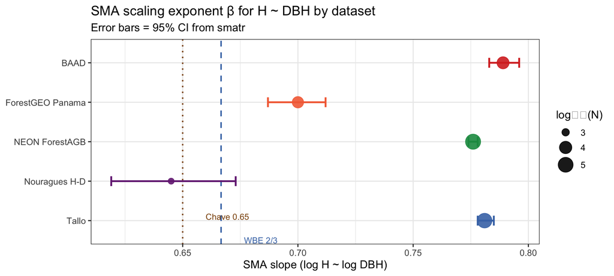

```r
# ── Purpose of this chunk ─────────────────────────────────────────────────────
# Dot plot of per-source SMA slopes with 95% CI error bars.
# Reference lines mark the two theoretical predictions:
#   2/3 (WBE/pipe model, blue dashed)
#   0.65 (Chave et al. 2005, brown dotted)
# Point size is proportional to log₁₀(N) so the reader can see which estimates
# are from large vs small datasets; this does not weight the analysis.
source_pal <- c(
  "BAAD"             = "#d73027",
  "Tallo"            = "#4575b4",
  "NEON ForestAGB"   = "#1a9850",
  "ForestGEO Panama" = "#f46d43",
  "Nouragues H-D"    = "#762a83"
)

sma_hdbh_tab |>
  mutate(source = factor(source, levels = rev(sort(unique(source))))) |>
  ggplot(aes(x = SMA_slope, y = source, color = source)) +
  geom_vline(xintercept = 2/3,  linetype = "dashed", color = "#4575b4",
             linewidth = 0.8) +  # WBE prediction
  geom_vline(xintercept = 0.65, linetype = "dotted", color = "#8c510a",
             linewidth = 0.8) +  # Chave 2005 empirical
  geom_errorbarh(aes(xmin = CI_lo, xmax = CI_hi),
                 height = 0.25, linewidth = 1) +  # 95% CI from smatr
  geom_point(aes(size = log10(n)), alpha = 0.9) +
  scale_color_manual(values = source_pal, guide = "none") +
  scale_size_continuous(range = c(3, 8),
                        name  = "log\u2081\u2080(N)",
                        breaks = c(2, 3, 4, 5)) +
  annotate("text", x = 2/3  + 0.01, y = 0.5,
           label = "WBE 2/3",    color = "#4575b4", hjust = 0, size = 3.5) +
  annotate("text", x = 0.65 + 0.01, y = 1.1,
           label = "Chave 0.65", color = "#8c510a", hjust = 0, size = 3.5) +
  labs(
    x = "SMA slope (log H ~ log DBH)",
    y = NULL,
    title = "SMA scaling exponent \u03b2 for H ~ DBH by dataset",
    subtitle = "Error bars = 95% CI from smatr"
  )
```

## 3.2 OLS vs SMA slope comparison

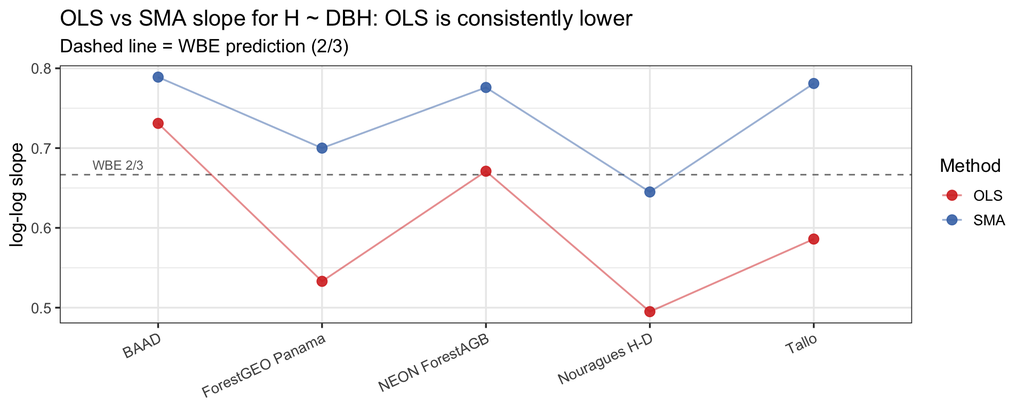

```r
# ── Purpose of this chunk ─────────────────────────────────────────────────────
# Paired comparison showing OLS and SMA slopes for each source on the same panel.
# Key scientific point: OLS minimises squared residuals in Y only, so when X (DBH)
# has measurement error, OLS systematically underestimates the true slope (attenuation
# bias). SMA treats both axes symmetrically and is the appropriate method when the
# goal is to estimate the line of best fit (not to predict Y from X).
# The consistent gap between OLS and SMA across all sources confirms this bias.
sma_hdbh_tab |>
  select(source, OLS_slope, SMA_slope, n) |>
  pivot_longer(cols = c(OLS_slope, SMA_slope),
               names_to = "method", values_to = "slope") |>
  mutate(method = recode(method, OLS_slope = "OLS", SMA_slope = "SMA"),
         source = factor(source, levels = sort(unique(source)))) |>
  ggplot(aes(x = source, y = slope, color = method, group = method)) +
  geom_hline(yintercept = 2/3, linetype = "dashed", color = "grey50") +  # WBE reference
  geom_line(linewidth = 0.6, alpha = 0.5) +   # line connecting OLS-SMA pair per source
  geom_point(size = 3, alpha = 0.9) +
  scale_color_manual(values = c(OLS = "#d73027", SMA = "#4575b4"),
                     name = "Method") +
  annotate("text", x = 0.6, y = 2/3 + 0.012,
           label = "WBE 2/3", color = "grey40", hjust = 0, size = 3.2) +
  labs(
    x = NULL, y = "log-log slope",
    title = "OLS vs SMA slope for H ~ DBH: OLS is consistently lower",
    subtitle = "Dashed line = WBE prediction (2/3)"
  ) +
  theme(axis.text.x = element_text(angle = 25, hjust = 1))
```